# Interactive Data Science

January 6, 2019

## Interactive?

Yes!!! Interactive means allowing YOU to select which is which like a calculator. YOU select the inputs and the app will give you the output based on your selected inputs. Isn't that great?

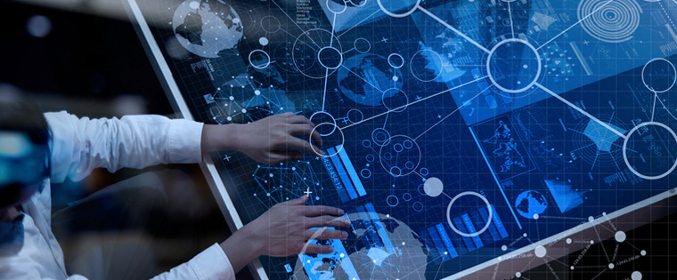

## Inspiration

The inspiration behind this application is the inspiring words and lectures from Andrew Ng and course professors, Roger Peng, Jeff Leek, and Brian Caffo. I see how amazing machine learning models has become and how it contributed greatly in improving prediction and strategic solutions.

With this, I think of utilizing this models like a calculator where there is a dataset as "numbers", models as "settings", and functions as "tools". The growth of technological advancement is tremendous and this idea of Interactive Data Science may soon be realized in the academe, research, and even business.

## Selections

In this application, user is given three selections: dataset, dependent variable, and models. The available datasets are: Motor Trend Car Road Tests (mtcars), Swiss Fertility and Socioeconomic Indicators (1888) Data (swiss), and New York Air Quality Measurements (airquality). The dependent variable is based on the given variables in the chosen dataset. The models available are: Random Forest, Generalized Linear Regression, and Trees.

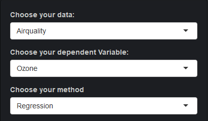

## Output

Based from the selected inputs, the user can see the dataset, the summary of the model, and the relevant plot. With these, the user can perform basic analysis.

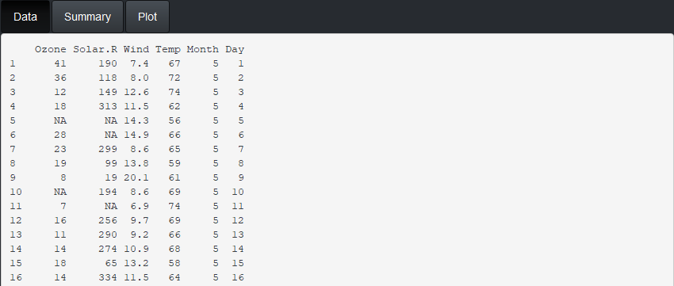

## Future

Amassing the data science toolbox into a calculator gives you a toolkit in your day-to-day analysis and research making it more convenient and easy-to-use. The future of Interactive Data Science begins here!

[figure not shown]